# EFA with indices n>100 in the adult sample

```r
library(tidyverse)
library(psych)
library(GPArotation)
library(broom)
```

```r
#df <- read.csv("~/GitHub/lendulet_language_SL/SEM/dataframes/SEM_df.csv")
df = read.csv(readline("Path of dataframe (e.g., C:/experiment/df.csv): "))
C:/Users/Kriszti/GitHub/lendulet_language_SL/SEM/dataframes/SEM_df.csv
df[, 17:33] = sapply(df[, 17:33], scale)
df[, 35:56] = sapply(df[, 35:56], scale)
df[, 58:74] = sapply(df[, 58:74], scale)
df = df %>%
  filter(age_years > 14)
```

# 1. Statistical learning measures

(Variables are in different rows to be able to be removed by commenting them out)

Parallel analyses plot

```
Parallel analysis suggests that the number of factors =  2  and the number of components =  NA
```

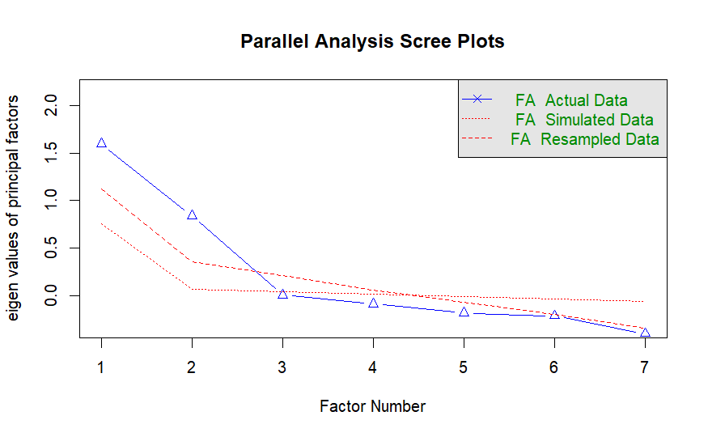

```r
df %>%
  select(
    #SEGM_AL_medRT_train,
    SEGM_AL_medRT_TRN3_RND4,
    SEGM_AL_medRT_RND4_REC5,
    #SEGM_AL_ACC_train,
    #SEGM_AL_ACC_TRN3_RND4,
    #SEGM_AL_ACC_RND4_REC5,
    #SEGM_AL_2AFC_bigram,
    SEGM_AL_2AFC_trigram,
    SEGM_AL_SEGM_prod_data,
    #AGL_ACC_train,
    AGL_2AFC_phr,
    AGL_2AFC_sent,
    AGL_prod
  ) %>%
    fa.parallel(fm = "ml", fa = "fa")
```

Factor building

1. iteration – excluding AGL_ACC_train due to weak loading, low commonality and high uniqueness –> single-score factor?
2. iteration – excluding SEGM_AL_bigram due to weak loading, low commonality and high uniqueness –> single-score factor?
3. iteration – excluding SEGM_AL_ACC_train due to relatively weak loading in a factor with a Heywood case
4. iteration – excluding SEGM_AL_medRT_train due to relatively weak loading in a factor with a Heywood case FINAL

Remaining question: should we include SEGM_AL_2AFC_trigram? Relatively low factor loading, but including this doesn’t decrease omega (latent reliability)

```r
SL_EFA = df %>%
  select(
    #SEGM_AL_medRT_train,
    SEGM_AL_medRT_TRN3_RND4,
    SEGM_AL_medRT_RND4_REC5,
    #SEGM_AL_ACC_train,
    #SEGM_AL_ACC_TRN3_RND4,
    #SEGM_AL_ACC_RND4_REC5,
    #SEGM_AL_2AFC_bigram,
    SEGM_AL_2AFC_trigram,
    SEGM_AL_SEGM_prod_data,
    #AGL_ACC_train,
    AGL_2AFC_phr,
    AGL_2AFC_sent,
    AGL_prod
  ) %>%
  # maximum likelihood
  fa(
    nfactors = 2,
    fm = "ml",
    rotate = "Promax",
    use = "pairwise",
    cor = "cor",
    scores = "regression",
    missing = TRUE,
    impute = "mean"
    )
```

```r
summary(SL_EFA)
```

```
Factor analysis with Call: fa(r = ., nfactors = 2, rotate = "Promax", scores = "regression",
    missing = TRUE, impute = "mean", fm = "ml", use = "pairwise",
    cor = "cor")

Test of the hypothesis that 2 factors are sufficient.
The degrees of freedom for the model is 8  and the objective function was  0.02
The number of observations was  1562  with Chi Square =  23.66  with prob <  0.0026

The root mean square of the residuals (RMSA) is  0.02
The df corrected root mean square of the residuals is  0.03

Tucker Lewis Index of factoring reliability =  0.978
RMSEA index =  0.035  and the 10 % confidence intervals are  0.019 0.052
BIC =  -35.17
 With factor correlations of
     ML1  ML2
ML1 1.00 0.26
ML2 0.26 1.00
```

```r
SL_EFA$loadings
```

```
Loadings:
                        ML1    ML2
SEGM_AL_medRT_TRN3_RND4  0.941
SEGM_AL_medRT_RND4_REC5  0.746
SEGM_AL_2AFC_trigram     0.199  0.322
SEGM_AL_SEGM_prod_data   0.189  0.402
AGL_2AFC_phr            -0.136  0.415
AGL_2AFC_sent                   0.636
AGL_prod                -0.127  0.640

                 ML1   ML2
SS loadings    1.553 1.257
Proportion Var 0.222 0.180
Cumulative Var 0.222 0.401
```

```r
tidy(SL_EFA$uniquenesses)
```

| names | x |
| --- | --- |
| SEGM_AL_medRT_TRN3_RND4 | 0.1429153 |
| SEGM_AL_medRT_RND4_REC5 | 0.4542567 |
| SEGM_AL_2AFC_trigram | 0.8235035 |
| SEGM_AL_SEGM_prod_data | 0.7639517 |
| AGL_2AFC_phr | 0.8383372 |
| AGL_2AFC_sent | 0.6017459 |
| AGL_prod | 0.6156874 |

```r
df %>%
  select(
    SEGM_AL_2AFC_trigram,
    SEGM_AL_SEGM_prod_data,
    AGL_2AFC_phr,
    AGL_2AFC_sent,
    AGL_prod
  ) %>%
  cor(use = "pairwise.complete.obs") %>%
omega(nfactors = 1,
      fm = "ml")
```

[output not shown]

# 2. General cognitive measures

Parallel analyses plot

[output not shown]

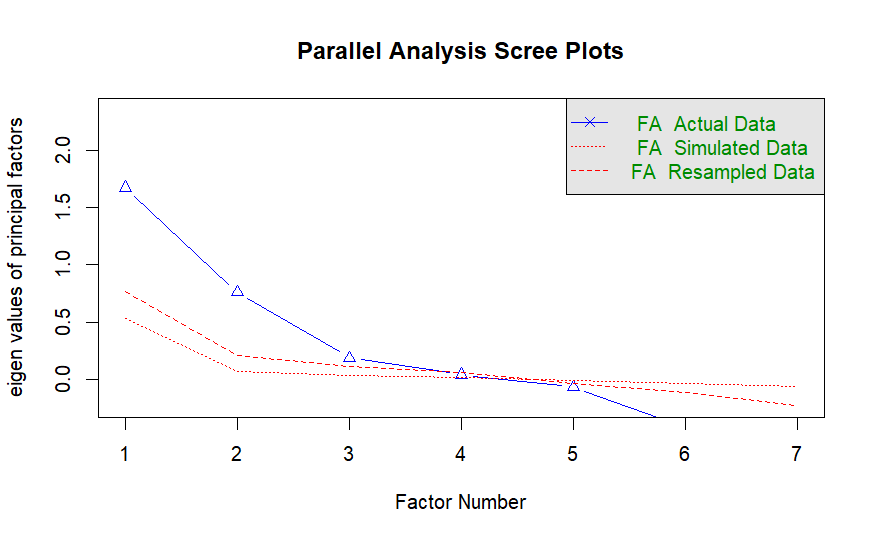

```r
df %>%
  select(
    PROC_SPEED_vis_RT_med,
    PROC_SPEED_ac_RT_med,
    #PROC_SPEED_vis_dec_RT_med,
    digit_span_forward_span,
    digit_span_backward_span,
    n_back_nback_1_dprime,
    n_back_nback_2_dprime,
    n_back_nback_3_dprime,
    #stroop_RT_score,
    #stroop_ACC_score,
    #simon_RT_score,
    #simon_ACC_score
  ) %>%
    fa.parallel(fm = "ml", fa = "fa")
```

Factor building

1. iteration – excluding simon_ACC_score due to low factor loading etc. –> single score factor?
2. iteration – excluding simon_RT_score due to low factor loading etc. –> single score factor?
3. iteration – excluding PROC_SPEED_vis_dec_RT_med because it is a single score factor

```r
GC_EFA = df %>%
  select(
    PROC_SPEED_vis_RT_med,
    PROC_SPEED_ac_RT_med,
    #PROC_SPEED_vis_dec_RT_med,
    digit_span_forward_span,
    digit_span_backward_span,
    n_back_nback_1_dprime,
    n_back_nback_2_dprime,
    n_back_nback_3_dprime,
    #stroop_RT_score,
    #stroop_ACC_score,
    #simon_RT_score,
    #simon_ACC_score
  ) %>%
  fa(nfactors = 3, fm ="ml", rotate = "Promax")
```

```r
summary(GC_EFA)
```

```
Factor analysis with Call: fa(r = ., nfactors = 3, rotate = "Promax", fm = "ml")

Test of the hypothesis that 3 factors are sufficient.
The degrees of freedom for the model is 3  and the objective function was  0.01
The number of observations was  1562  with Chi Square =  8.87  with prob <  0.031

The root mean square of the residuals (RMSA) is  0.01
The df corrected root mean square of the residuals is  0.02

Tucker Lewis Index of factoring reliability =  0.982
RMSEA index =  0.035  and the 10 % confidence intervals are  0.009 0.063
BIC =  -13.19
 With factor correlations of
      ML2   ML3   ML1
ML2  1.00  0.26 -0.26
ML3  0.26  1.00 -0.36
ML1 -0.26 -0.36  1.00
```

```r
GC_EFA$loadings
```

```
Loadings:
                         ML2    ML3    ML1
PROC_SPEED_vis_RT_med           -0.201  0.421
PROC_SPEED_ac_RT_med             0.115  1.049
digit_span_forward_span          0.686
digit_span_backward_span         0.900  0.125
n_back_nback_1_dprime     0.528
n_back_nback_2_dprime     0.931
n_back_nback_3_dprime     0.617

                ML2   ML3   ML1
SS loadings    1.54 1.338 1.300
Proportion Var 0.22 0.191 0.186
Cumulative Var 0.22 0.411 0.597
```

```r
tidy(GC_EFA$uniquenesses)
```

| names | x |
| --- | --- |
| PROC_SPEED_vis_RT_med | 0.690020067 |
| PROC_SPEED_ac_RT_med | 0.004999973 |
| digit_span_forward_span | 0.525453072 |
| digit_span_backward_span | 0.269162736 |
| n_back_nback_1_dprime | 0.708269879 |
| n_back_nback_2_dprime | 0.178364281 |
| n_back_nback_3_dprime | 0.610286540 |

```r
df %>%
  select(

  ) %>%
  cor(use = "pairwise.complete.obs") %>%
omega(nfactors = 1,
      fm = "ml")
```

# 3. Language measures

Parallel analyses plot

```
Parallel analysis suggests that the number of factors =  3  and the number of components =  NA
```

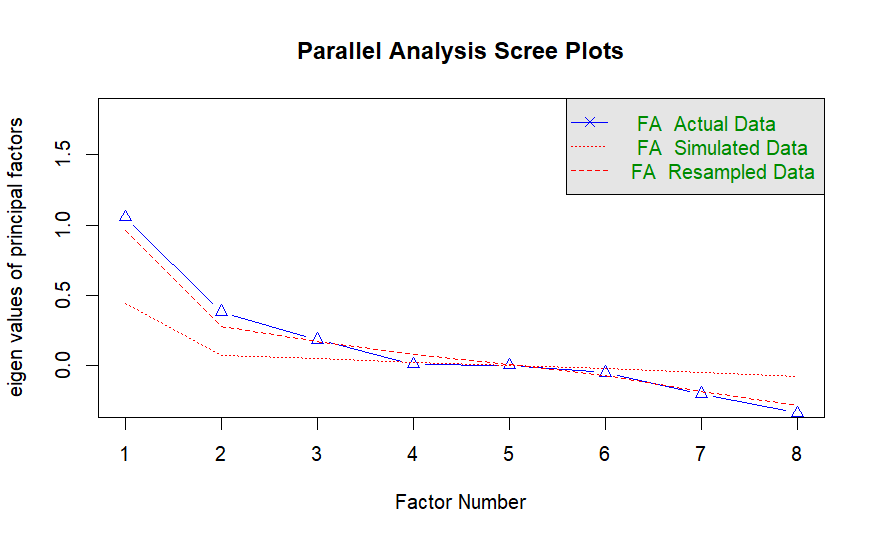

```r
df %>%
  select(
    MENYET_mean_ACC_all,
    OMR_read_syls,
    predictive_RT_score,
    predictive_ACC_score,
    selfpaced_target_RT_diff_GP,
    selfpaced_plus1_RT_diff_mellekmondat,
    selfpaced_target_RT_diff_sertes,
    trog_pragm_ACC_mean
  ) %>%
    fa.parallel(fm = "ml", fa = "fa")
```

Factor building

1. iteration – excluding mellekmondat: 0 commonality
2. iteration – excluding predictive ACC due to low factor loading – excluding predictive RT –> single score factor

Remaining question: very low commonality of MENYET

```r
LA_EFA = df %>%
  select(
    MENYET_mean_ACC_all,
    OMR_read_syls,
    predictive_RT_score,
    predictive_ACC_score,
    selfpaced_target_RT_diff_GP,
    selfpaced_plus1_RT_diff_mellekmondat,
    selfpaced_target_RT_diff_sertes,
    trog_pragm_ACC_mean
  ) %>%
  fa(nfactors = 1, fm ="ml", rotate = "Promax")
```

```r
summary(LA_EFA)
```

```
Factor analysis with Call: fa(r = ., nfactors = 1, rotate = "Promax", fm = "ml")

Test of the hypothesis that 1 factor is sufficient.
The degrees of freedom for the model is 20  and the objective function was  0.2
The number of observations was  1562  with Chi Square =  309.41  with prob <  9.6e-54

The root mean square of the residuals (RMSA) is  0.08
The df corrected root mean square of the residuals is  0.09

Tucker Lewis Index of factoring reliability =  0.489
RMSEA index =  0.096  and the 10 % confidence intervals are  0.087 0.106
BIC =  162.34
```

```r
LA_EFA$loadings
```

```
Loadings:
                                     ML1
MENYET_mean_ACC_all                   0.195
OMR_read_syls                         0.491
predictive_RT_score                   0.190
predictive_ACC_score                  0.165
selfpaced_target_RT_diff_GP          -0.549
selfpaced_plus1_RT_diff_mellekmondat
selfpaced_target_RT_diff_sertes      -0.598
trog_pragm_ACC_mean                   0.215

                 ML1
SS loadings    1.049
Proportion Var 0.131
```

```r
tidy(LA_EFA$communality)
```

| names | x |
| --- | --- |
| MENYET_mean_ACC_all | 0.03813463 |
| OMR_read_syls | 0.24073792 |
| predictive_RT_score | 0.03606111 |
| predictive_ACC_score | 0.02719142 |
| selfpaced_target_RT_diff_GP | 0.30175978 |
| selfpaced_plus1_RT_diff_mellekmondat | 0.00120082 |
| selfpaced_target_RT_diff_sertes | 0.35778647 |
| trog_pragm_ACC_mean | 0.04622359 |

```r
df %>%
  select(
    MENYET_mean_ACC_all,
    trog_pragm_ACC_mean
  ) %>%
  cor(use = "pairwise.complete.obs") %>%
omega(nfactors = 1,
      fm = "ml")
```